# Assignment 07

Craig Beuerlein

Sections A Monday, September 23, 2019

# Study

A study was conducted to determine the effects of alcohol on human reaction times. Fifty-seven adult individuals within two age groups were recruited for this study and were randomly allocated into one of three alcohol treatment groups – a **control** where the subjects remain sober during the entire study, a **moderate** group were the subject is supplied alcohol but is limited in such a way that their blood alcohol content (BAC) remains under the legal limit to drive (BAC of 0.08) and a group that received a **high** amount of alcohol to which their BAC may exceed the legal limit for driving. Each subject was trained on a video game system and their reaction time (in milliseconds) to a visual stimulus was recorded at 7 time points 30 minutes apart (labeled T0=0, T1=30, T2=60 and so on). At time point T0, all subjects were sober and those in one of the alcohol consumption groups began drinking after the first measured reaction time (controlled within the specifications outlined). The researcher is interested in determining the influence alcohol and age (namely, is reaction time different for those in the 20s versus 30s) has on reaction times.

The task for today is to do a complete analysis for this study and dig into the effects of alcohol, age and time have on reaction times.

# Data input and wrangling

```r
alcohol <-read.csv("alcoholReaction.csv")
head(alcohol)
```

```
##   Subject Age Alcohol    T0    T1    T2    T3    T4    T5    T6
## 1       1  24 Control 255.3 254.8 256.4 255.1 257.0 256.1 257.0
## 2       2  34 Control 250.1 249.2 249.0 248.0 248.0 248.9 248.1
## 3       3  31 Control 248.2 247.1 246.9 246.7 246.0 246.0 247.0
## 4       4  24 Control 253.9 253.8 254.9 254.1 253.2 254.1 255.0
## 5       5  38 Control 250.0 251.0 250.0 249.9 248.8 249.1 249.9
## 6       6  38 Control 246.0 248.0 247.0 248.1 248.1 246.9 244.0
```

```r
alcohol <- alcohol %>%
  mutate(Age=case_when(Age<31 ~ "20s",
                       Age %in% 31:40 ~ "30s"))
head(alcohol)
```

```
##   Subject Age Alcohol    T0    T1    T2    T3    T4    T5    T6
## 1       1 20s Control 255.3 254.8 256.4 255.1 257.0 256.1 257.0
## 2       2 30s Control 250.1 249.2 249.0 248.0 248.0 248.9 248.1
## 3       3 30s Control 248.2 247.1 246.9 246.7 246.0 246.0 247.0
## 4       4 20s Control 253.9 253.8 254.9 254.1 253.2 254.1 255.0
## 5       5 30s Control 250.0 251.0 250.0 249.9 248.8 249.1 249.9
## 6       6 30s Control 246.0 248.0 247.0 248.1 248.1 246.9 244.0
```

```r
alcohol.tall <- alcohol %>%
  gather (key=Time, value=Reaction, c(T0, T1, T2, T3, T4, T5, T6))
head(alcohol.tall)
```

```
##   Subject Age Alcohol Time Reaction
## 1       1 20s Control   T0    255.3
## 2       2 30s Control   T0    250.1
## 3       3 30s Control   T0    248.2
## 4       4 20s Control   T0    253.9
## 5       5 30s Control   T0    250.0
## 6       6 30s Control   T0    246.0
```

```r
alcohol.tall <- alcohol.tall %>%
  mutate(Subject=as.factor(Subject),
         Alcohol=factor(Alcohol, levels=c("Control", "Moderate", "High")))
```

# Exploratory Data Analysis

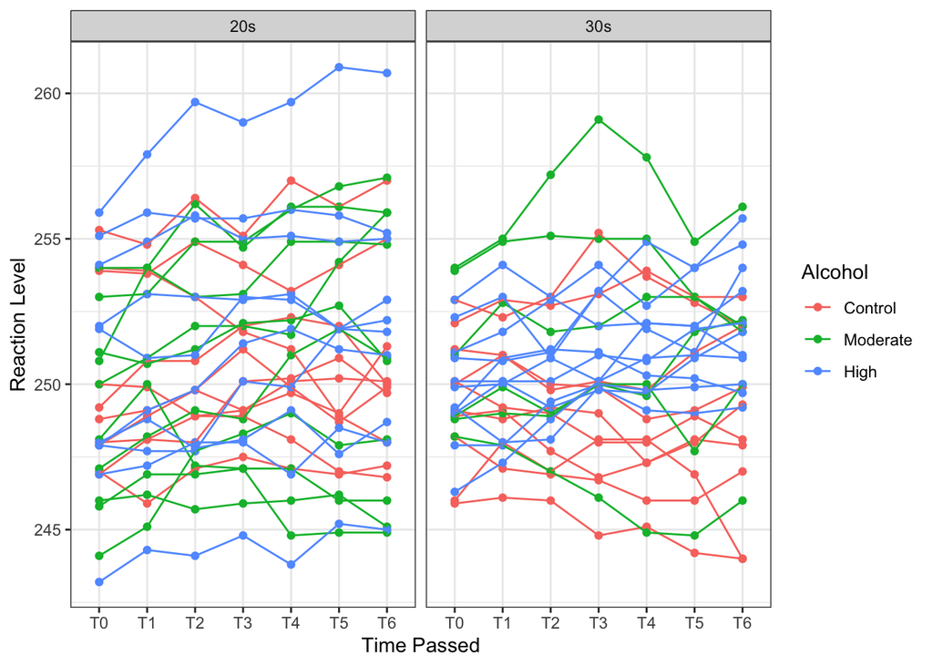

```r
ggplot(alcohol.tall, aes(x=Time,y=Reaction, color=Alcohol, group=Subject))  +
  stat_summary(fun.y=mean, geom="point") +
  stat_summary(fun.y=mean, geom="line") +
  labs(y="Reaction Level", x="Time Passed") +
  theme_bw()+
  facet_wrap(~Age)
```

# Model fitting and analysis

```r
alcohol.anova <- aov(Reaction ~ Time*Alcohol*Age + Error(Subject/Time), data=alcohol.tall)
summary(alcohol.anova)
```

```
##
## Error: Subject
##             Df Sum Sq Mean Sq F value Pr(>F)
## Alcohol      2    143   71.44   1.026  0.366
## Age          1     18   17.78   0.255  0.616
## Alcohol:Age  2     93   46.31   0.665  0.519
## Residuals   51   3553   69.66
##
## Error: Subject:Time
##                   Df Sum Sq Mean Sq F value   Pr(>F)
## Time               6   50.3   8.386   6.929 6.45e-07 ***
## Time:Alcohol      12   40.5   3.377   2.790  0.00125 **
## Time:Age           6    9.7   1.621   1.339  0.23927
## Time:Alcohol:Age  12   13.8   1.150   0.950  0.49702
## Residuals        306  370.4   1.210
## ---
## Signif. codes:  0 '***' 0.001 '**' 0.01 '*' 0.05 '.' 0.1 ' ' 1
```

# Multiple Comparison Follow ups

```r
alcohol.mc <- emmeans(alcohol.anova, "Alcohol","Time")
```

```
## Note: re-fitting model with sum-to-zero contrasts
```

```
## NOTE: Results may be misleading due to involvement in interactions
```

```r
contrast(alcohol.mc, "trt.vs.ctrl", ref=1)
```

```
## Time = T0:
##  contrast           estimate   SE   df t.ratio p.value
##  Moderate - Control    0.130 1.13 62.1 0.115   0.9848
##  High - Control        0.316 1.04 62.1 0.305   0.9216
##
## Time = T1:
##  contrast           estimate   SE   df t.ratio p.value
##  Moderate - Control    0.807 1.13 62.1 0.712   0.6931
##  High - Control        0.732 1.04 62.1 0.706   0.6971
##
## Time = T2:
##  contrast           estimate   SE   df t.ratio p.value
##  Moderate - Control    1.000 1.13 62.1 0.883   0.5828
##  High - Control        0.940 1.04 62.1 0.907   0.5677
##
## Time = T3:
##  contrast           estimate   SE   df t.ratio p.value
##  Moderate - Control    1.187 1.13 62.1 1.048   0.4789
##  High - Control        1.529 1.04 62.1 1.476   0.2537
##
## Time = T4:
##  contrast           estimate   SE   df t.ratio p.value
##  Moderate - Control    1.458 1.13 62.1 1.288   0.3426
##  High - Control        1.730 1.04 62.1 1.669   0.1798
##
## Time = T5:
##  contrast           estimate   SE   df t.ratio p.value
##  Moderate - Control    1.418 1.13 62.1 1.253   0.3612
##  High - Control        2.122 1.04 62.1 2.048   0.0836
##
## Time = T6:
##  contrast           estimate   SE   df t.ratio p.value
##  Moderate - Control    1.540 1.13 62.1 1.360   0.3064
##  High - Control        2.433 1.04 62.1 2.348   0.0420
##
## Results are averaged over the levels of: Age
## P value adjustment: dunnettx method for 2 tests
```

```r
confint(contrast(alcohol.mc, "trt.vs.ctrl", ref=1))
```

```
## Time = T0:
##  contrast           estimate   SE   df lower.CL upper.CL
##  Moderate - Control    0.130 1.13 62.1  -2.4455     2.71
##  High - Control        0.316 1.04 62.1  -2.0413     2.67
##
## Time = T1:
##  contrast           estimate   SE   df lower.CL upper.CL
##  Moderate - Control    0.807 1.13 62.1  -1.7689     3.38
##  High - Control        0.732 1.04 62.1  -1.6254     3.09
##
## Time = T2:
##  contrast           estimate   SE   df lower.CL upper.CL
##  Moderate - Control    1.000 1.13 62.1  -1.5755     3.58
##  High - Control        0.940 1.04 62.1  -1.4177     3.30
##
## Time = T3:
##  contrast           estimate   SE   df lower.CL upper.CL
##  Moderate - Control    1.187 1.13 62.1  -1.3889     3.76
##  High - Control        1.529 1.04 62.1  -0.8282     3.89
##
## Time = T4:
##  contrast           estimate   SE   df lower.CL upper.CL
##  Moderate - Control    1.458 1.13 62.1  -1.1172     4.03
##  High - Control        1.730 1.04 62.1  -0.6272     4.09
##
## Time = T5:
##  contrast           estimate   SE   df lower.CL upper.CL
##  Moderate - Control    1.418 1.13 62.1  -1.1572     3.99
##  High - Control        2.122 1.04 62.1  -0.2350     4.48
##
## Time = T6:
##  contrast           estimate   SE   df lower.CL upper.CL
##  Moderate - Control    1.540 1.13 62.1  -1.0355     4.12
##  High - Control        2.433 1.04 62.1   0.0759     4.79
##
## Results are averaged over the levels of: Age
## Confidence level used: 0.95
## Conf-level adjustment: dunnettx method for 2 estimates
```

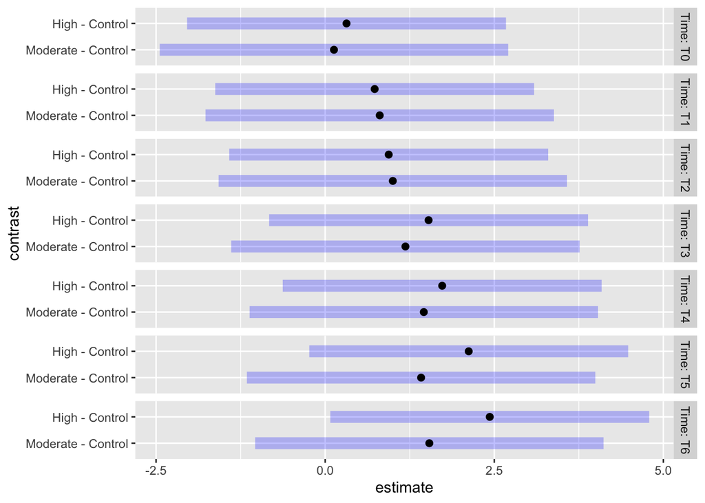

```r
plot(contrast(alcohol.mc, "trt.vs.ctrl", ref=1))
```

Note: We have two levels of *control* in this study, there is an explicit **Control** group and at time point T0 no subjects had been given a treatment, so it also operates as a control. Dunnett’s method for multiple comparison is most appropriate (see chapter 2.7 of the text).

# Conclusions